# V praktikum

Risto Hinno

Monday, May 18, 2015

# Andmete kraapimine veebist

## Sissejuhatus

Eva “Usin” Masin on esimeses praktikumis kohatud Mati “Raha” Masina vastand. Talle meeldib rutiinsus, andmete tuim kopeerimine ja sisestamine. Vabal ajal meeldib talle lugeda romaanisarja “Tõde ja õigus” - eelmine nädal luges ta kokku tähekombinatsiooni “pa” esinemissageduse. Homme pärast tööd jätkab ta “pb” esinemissageduse leidmisega.

Kahjuks oli eelnev tekst fiktsioon ning eva-laadsed kopeerijad surid välja koos neandertaallastega. Selles praktikumis vaatame, kuidas R-is ellu äratada tehis-Eva, kes oskab veebilehtedelt automaatselt infot eraldada ja selle transformeerida struktureeritud andmestikuks.

Täpsemalt, uurime

- kuidas eraldada Riigikogu hääletamistulemusi,
- kuidas eraldada Postimehe uudiste pealkirju,
- kuidas eraldada ilmajaama vaatlusandmeid.

Kaks esimest ülesannet õpetavad paketi rvest funktsionaalsust ja annavad sissejuhatuse veebikraapimisse minimalistlike veebilehtede põhjal.

## Ülesanne 1 (2 punkti) - CSS id

- Eralda [html koodis](http://andmeteadus.github.io/examples/html1.html) sinisena olev tekst muutujasse tekst. Kasuta paketti rvest.
- Vastava html koodiga saad mängida [siin](http://www.w3schools.com/html/tryit.asp?filename=tryhtml_css_id).
- Loe lühiülevaadet, [millest koosnevad veebilehed](http://andmeteadus.github.io/praktikum5_rvest_minimal).
- Uuri paketi rvest minimalistlikku [näidet](http://andmeteadus.github.io/praktikum5_rvest_minimal).
- Minimalistliku näite põhjal peaksid oskama eraldada lähtekoodis olevad 4 lõiku. Et eraldada lõik, kus id=“p01”, pead teadma, kuidas CSS-is tähistatakse id-sid. Suur vihje on olemas eelneva html koodi < style > blokis. Abiks võib-olla ka [CSS selektorite interaktiivne testnäide](http://www.w3schools.com/cssref/trysel.asp).

```r
library(rvest)
html_source ="http://andmeteadus.github.io/examples/html1.html"
page = html(html_source)
tekst=page %>%
    html_node("p#p01") %>%
    html_text()
tekst
```

```
## [1] "I am different."
```

## Ülesanne 2 (2 punkti) - CSS class

Eralda [html koodis](http://andmeteadus.github.io/examples/html2.html) punaselt olev tekst muutujasse tekst. Kasuta paketti rvest.

Vastava html koodiga saad mängida [siin](http://www.w3schools.com/html/tryit.asp?filename=tryhtml_css_class).

Lõpptulemuse peaks olema selline: tekst = c(“I am different.”, “I am different too.”)

```r
html_source ="http://andmeteadus.github.io/examples/html2.html"
page = html(html_source)
tekst2=page %>%
    html_nodes("p.error") %>%
    html_text()
tekst2
```

```
## [1] "I am different."     "I am different too."
```

## Ülesanne 3 (2 punkti)

Eralda Riigikogu hääletamistulemuste veebilehe [html lähtekoodist](http://www.riigikogu.ee/?op=ems&page=haaletus&hid=a85129ed-4873-4b9d-ac37-4788b6587fa0&), mitu saadikut hääletas kooseluseaduse eelnõu:

- poolt
- vastu
- oli erapooletu
- ei hääletanud

Praktikumis tutvusime, kuidas brauseri veebiarendus tööriistadega leida üles lähtekoodist vajalikud kohad. Variandid olid:

- Chrome’is vajuta parem klikk ja “inspekteeri elementi”. Alernatiivid on klahvikombinatsioon Ctrl + Shift + I või klahv F12. vahendiga [selectorgadget](http://selectorgadget.com/)
- Need muudavad lähtekoodis õige klassi, id või sildi leidmise oluliselt lihtsamaks. Mõnes olukorras on kasulikum üks variant, mõnes teine.

```r
html_source ="http://www.riigikogu.ee/tegevus/tooulevaade/haaletused/haaletustulemused-kohalolekukontroll/a85129ed-4873-4b9d-ac37-4788b6587fa0/"
page = html(html_source)
haaletus=page %>%
    html_nodes("li a span") %>%
    html_text()
haaletus
```

```
## [1] "40"  "38"  "0"   "10"  " 88" " 13"
```

## Ülesanne 4 (2 punkti)

Eralda kooseluseaduse eelnõu hääletamistulemuste veebilehe [html lähtekoodist](http://www.riigikogu.ee/?op=ems&page=haaletus&hid=a85129ed-4873-4b9d-ac37-4788b6587fa0&) andmetabel, kus on 101 rida ning tunnused nr, nimi, otsus, fraktsioon.

Vihje: kasuta funktsiooni html_table

Kirjuta vastav kood funktsiooniks extract_table (seda funktsiooni läheb vaja järgmises ülesandes, kus eraldad kõigi Riigikogu XII hääletuste kohta vastava tabeli). Sisendiks on kas veebilehe url, faili lokaalne asukoht või sõne. Funktsioon peab tagastama vastava data.frame-i (pane tähele, et su funktsioon ei tagastaks listi, milles on üks data.frame).

```r
library(knitr)
html_source ="http://www.riigikogu.ee/tegevus/tooulevaade/haaletused/haaletustulemused-kohalolekukontroll/a85129ed-4873-4b9d-ac37-4788b6587fa0/"
page = html(html_source)

haaletus=page %>%
    html_nodes(".table.table.table-striped.full-bars") %>%
    html_table()
#siit saan data frame 101 liikme, erkonna ja hööletustulemusega, nr-d võtan
#zipitud tabelitest, kuna vahepeal on kodulehte muudetud
sub=haaletus[1]
sub2=as.data.frame(sub)
#puhastan otsuse poolt ja asendan tabelisse
junn=gsub( " ", "",sub2$Otsus)
junn2=gsub( "\n\n", "",junn)
junn3=gsub( "^Poolt", "",junn2)
junn3=gsub( "^Vastu", "",junn3)
junn3=gsub( "^EiHääletanud", "",junn3)
junn3=gsub( "^Puudub", "",junn3)
junn3=gsub( "EiHääletanud", "Ei Hääletanud",junn3)
sub2$Otsus=junn3
kable(sub2)
```

| Nimi | Otsus | Fraktsioon |
| --- | --- | --- |
| Arto Aas | Poolt | Eesti Reformierakonna fraktsioon |
| Jaak Aaviksoo | Vastu | Isamaa ja Res Publica Liidu fraktsioon |
| Rein Aidma | Poolt | Eesti Reformierakonna fraktsioon |
| Annely Akkermann | Vastu | Isamaa ja Res Publica Liidu fraktsioon |
| Jaak Allik | Poolt | Sotsiaaldemokraatliku Erakonna fraktsioon |
| Peep Aru | Vastu | Eesti Reformierakonna fraktsioon |
| Maimu Berg | Poolt | Sotsiaaldemokraatliku Erakonna fraktsioon |
| Deniss Boroditš | Vastu | Fraktsiooni mittekuuluvad Riigikogu liikmed |
| Enn Eesmaa | Puudub | Eesti Keskerakonna fraktsioon |
| Eldar Efendijev | Vastu | Eesti Keskerakonna fraktsioon |
| Ene Ergma | Puudub | Isamaa ja Res Publica Liidu fraktsioon |
| Igor Gräzin | Vastu | Eesti Reformierakonna fraktsioon |
| Margus Hanson | Puudub | Eesti Reformierakonna fraktsioon |
| Aare Heinvee | Ei Hääletanud | Eesti Reformierakonna fraktsioon |
| Andres Herkel | Vastu | Fraktsiooni mittekuuluvad Riigikogu liikmed |
| Remo Holsmer | Poolt | Eesti Reformierakonna fraktsioon |
| Kaia Iva | Vastu | Isamaa ja Res Publica Liidu fraktsioon |
| Jüri Jaanson | Poolt | Eesti Reformierakonna fraktsioon |
| Tatjana Jaanson | Poolt | Sotsiaaldemokraatliku Erakonna fraktsioon |
| Kalle Jents | Poolt | Eesti Reformierakonna fraktsioon |
| Tõnu Juul | Vastu | Eesti Reformierakonna fraktsioon |
| Etti Kagarov | Poolt | Sotsiaaldemokraatliku Erakonna fraktsioon |
| Lembit Kaljuvee | Poolt | Fraktsiooni mittekuuluvad Riigikogu liikmed |
| Kalev Kallemets | Poolt | Eesti Reformierakonna fraktsioon |
| Kalev Kallo | Vastu | Eesti Keskerakonna fraktsioon |
| Siim Kiisler | Vastu | Isamaa ja Res Publica Liidu fraktsioon |
| Aivar Kokk | Vastu | Isamaa ja Res Publica Liidu fraktsioon |
| Mihhail Korb | Vastu | Eesti Keskerakonna fraktsioon |
| Valeri Korb | Vastu | Eesti Keskerakonna fraktsioon |
| Siret Kotka | Puudub | Eesti Keskerakonna fraktsioon |

[output cut: 71 more lines]

Funktsiooni ma ei tee, kuna Riigikogu kodulehte on uuendatud ja funktsioon ei töötaks järgnevate asjade peal.

## Ülesanne 5 (5 punkti) - andmestiku ehitamine

Ülesandes 4 tegid läbi Riigikogu saadikute hääletamistulemuste eraldamise kooseluseaduse korral. Failis htmls.zip on olemas veebilehed kõigi Riigikogu XII hääletuste kohta. Sinu ülesandeks on koostada andmetabel, kus ridades on Riigikogu saadiku nimi ja veergudes kõik hääletamiskorrad. Seda andmestikku läheb vaja järgmises praktikumis, kus uurime hääletamismustreid.

Kõigepealt paki lahti zip fail ning loe R-i sisse kõigi html failide nimed.

Näpunäide: Järgnev kood loeb sisse kõik muutujas filenames olevad csv andmestikud ning tekitab neist listi.

list_of_dataframes = list() for(i in 1:length(filenames)){ temp = read.csv(filenames[i]) list_of_dataframes[[i]] = temp }

Praegu pole sul read.csv käsuga midagi peale hakata, sest tegeleme html failidega. Kasuta ülesandes 4 kirjutatud funktsiooni extract_table. Eelneva for-tsükli asemel võid kasutada funktsiooni lapply.

Lisa igal tsükli sammul andmestikule hääletuse indeks või muu identifikaator. Näiteks temp$haaletus = i.

Nüüdseks peaksid olema saanud listi, mille elementideks on erinevad andmetabelid (kõiki faile kasutades peaks nende koguarv olema 1845). Tee nendest andmetabelitest üks suur (pikk) andmetabel, paigutades need üksteise otsa. Seda aitab teha paketi dplyr funktsioon rbind_all. Tulemuseks peaksid saama andmetabeli, mille ridade arv on 101 * “sinu kasutatud failide arv”.

Muuda pikk andmetabel laiaks. Seda aitab teha paketi reshape2 käsk dcast. Uuri funktsiooni dcast minimalistlikku näidet [siit](http://andmeteadus.github.io/praktikum3_reshape/#dcast).

Kui kõik eelnev töötab, tee eelnev läbi kõikide html failidega. Ära kohku, kui kõikide html tabelite eraldamisega läheb aega 5 minutit või rohkem.

Soovitus: Kui oled eelneva ühe korra läbi teinud, pole vaja knitri raporti genereerimisel enam sedasama korrata. Saadud andmetabeli saad endale salvestada käsuga save(andmed, file=“riigikogu.RData”). Raportis võid muuta vastava koodiploki eval=FALSE.

```r
#funktsioon kõige pealt
extract_table=function(url) {
    html_source =url
    page = html(html_source)
    tabel=page %>%
        html_nodes("table.List") %>%
        html_table()%>%
        as.data.frame()
    tabel
}

#loen kõik failid sisse
filenames =list.files("./data/data", pattern = "*.html", full.names=TRUE)

list_of_dataframes = list()
for(i in 1:length(filenames)){
    temp = extract_table(filenames[i])
    temp$haaletus = i
    list_of_dataframes[[i]] = temp
}
#keevitan kokku
library(dplyr)
andmed=rbind_all(list_of_dataframes)

#Muudan pika andmetabeli laiaks
library(reshape2)
andmed_lai=dcast(andmed, Nimi~haaletus, value.var = "Otsus")
```

## Ülesanne 6

Ära kurvasta, kui sa ei saa absoluutselt kõiki pealkirju, 97% on praegu piisav.

```r
url="http://www.postimees.ee/"
page = html(url)
tekst=page %>%
    html_nodes(".frontHeading") %>%
    html_text()
#puhastame
tekst_puhas=gsub("\n", "", tekst)
#palkirjade lõppu korjab ka kommentaaride arvu, puhastame need välja
tekst_puhas=gsub("\\d*$", "", tekst_puhas)
#eemaldame tühjad stringid
tekst_puhas=tekst_puhas[tekst_puhas != ""]
kable(tekst_puhas)
```

| Saksamaa saadab tuleval aastal Eestisse roteeruva kompanii |
| --- |
| Kaja Kallas: kes otsustab, millised ideed on «napakad»? |
| Video: Kadõrovi õnnistusel sunniti 17-aastane neiu mõjuka politseülemaga abielluma |
| Piinlik video: Kanada hümni ajal kohatult käitnud Venemaa hokistaare ootab karistus |
| Finaalseeria kolib Tallinnasse: mida suudab Rock täna kalevlaste kodusaalis? |
| Stig ja Elina teenisid esimeses peaproovis publikult sooja aplausi |
| President Ilves: Euroopa vajab Saksamaa eeskuju |
| Pariis ja Moskva arutavad Mistralite küsimuse lahendamist |
| Fotod: Pirita jõe üks sild sai valmis |
| Kliendikaartide varjatud võlu |
| ÜLESKUTSE: saada foto oma vahvast lemmikust! |
| Ilma trennita rannavormi ei saavuta |
| Tasakaalustatud toitumine aitab hoida lemmiklooma tervena |
| Kuidas kassid aitavad ärevushäiretega lapsi? |
| Ratsutamisteraapia mõjub hästi nii patsiendi füüsilisele kui vaimsele seisundile |
| Kui kevadel vaevab stress ja kurnatus |
| ÜLESKUTSE: Küsi loomatundjalt nõu! |
| Tööõnnetus on suur risk nii tööandjale kui töötajale |
| Üha enam tuleb arvestada kriitiliste haiguste riskiga |
| Seda investorid ostaksid |
| Haigekassa: sotsiaalmaksu tuleks vähendada pensionikindlustuse arvelt |
| NATO: terroristid võivad üritada pagulaste seas Euroopasse pääseda |
| Makedoonia toimuvad kriisikõnelused |
| Silvano tütarfirma hakkab Iraanis pesu müüma |
| Bastionikäikudes avatakse sügisel raidkivimuuseum |
| Toitumisnõustaja soovitab: sidrun on justkui päike |
| Elina Born ja Stig Rästa: läheme lavale kindla tundega |
| Mart Normet: hämmastav, kuidas lavaga on mööda pandud! |
| René Vilbre: pidime kompromissidele «jah» ütlema |
| Eestlastel seisab ees Eurovisiooni-eksam |
| Kerry Põhja-Koreale: küberrünnakute toimepanijad võetakse vastutusele |

[output cut: 103 more lines]

## Ülesanne 7

Juhised:

- Riigi Ilmateenistus pakub värskeid ilmaandmeid [XML faili kujul](http://www.ilmateenistus.ee/teenused/ilmainfo/eesti-vaatlusandmed-xml/).
- Meie tegeleme Eesti vaatlusandmete [XML failiga](http://www.ilmateenistus.ee/ilma_andmed/xml/observations.php).
- Saa XML failist kätte iga ilmajaama õhurõhk.
- Saa XML failist kätte iga ilmajaama tuule kiirus.
- Tee neist õhurõhu ja tuule kiiruse scatterplot.

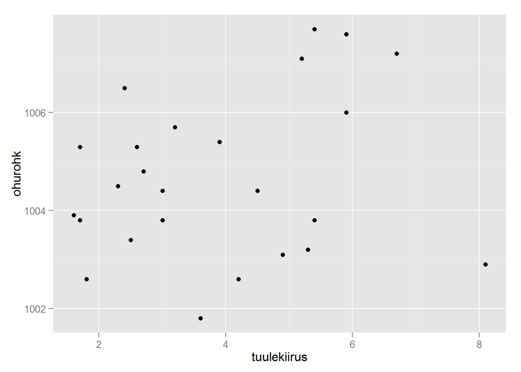

```r
url="http://www.ilmateenistus.ee/ilma_andmed/xml/observations.php"
page = html(url)

ohurohk=page %>%
    html_nodes("airpressure")%>%
    html_text()

tuulekiirus=page %>%
    html_nodes("windspeed") %>%
    html_text()

nimi=page %>%
    html_nodes("name")%>%
    html_text()

#teeme numericuks
ohurohk=as.numeric(as.character(ohurohk))
tuulekiirus=as.numeric(as.character(tuulekiirus))
ilm=data.frame(nimi, tuulekiirus, ohurohk)
#teeme graafiku
library(ggplot2)
ggplot(ilm, aes(x=tuulekiirus, y=ohurohk))+
    geom_point()
```

## Ülesanne 8

Eesti Loto veebilehel on toodud [statistika loositud pallide sagedusest](https://www.eestiloto.ee/osi/stats.do?lastDraws=250&gameCode=11&sort=frq0&action=searchNumbers). Eralda vastav tabel, kus veergudes on tunnused number, sagedus ja sagedus protsentides. selectorgadget veab sind siin alt ning kergem on lähtekoodi inspekteerida brauseris olevate tööriistadega (Chrome’s vajuta Ctrl + Shift + I või tee parem klikk ja vajuta inspekteeri elementi). Visualiseeri saadud andmetabelit. Tee näiteks tulpdiagramm, kus x-teljel on arvud 1-48 ning y-telg tähistab sagedust.

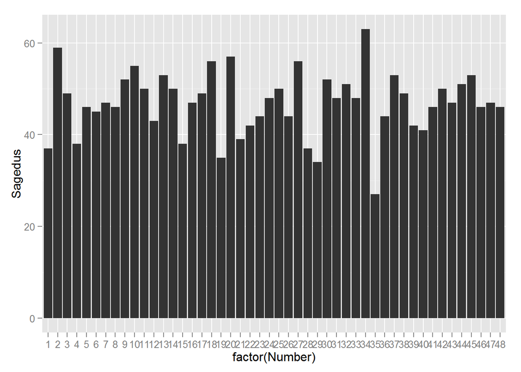

```r
html_source ="https://www.eestiloto.ee/osi/stats.do?lastDraws=250&gameCode=11&sort=frq0&action=searchNumbers"
#lingi osas tegin ise uue päringu ja võtsin siis lingi, algne peksis segast
page = html(html_source)
loto=page %>%
    html_nodes("table") %>%
    html_table(fill=T)

numbrid=as.data.frame(loto[5])
#graafik
library(ggplot2)
ggplot(numbrid, aes(x=factor(Number), y=Sagedus))+
    geom_bar(stat="identity")
```

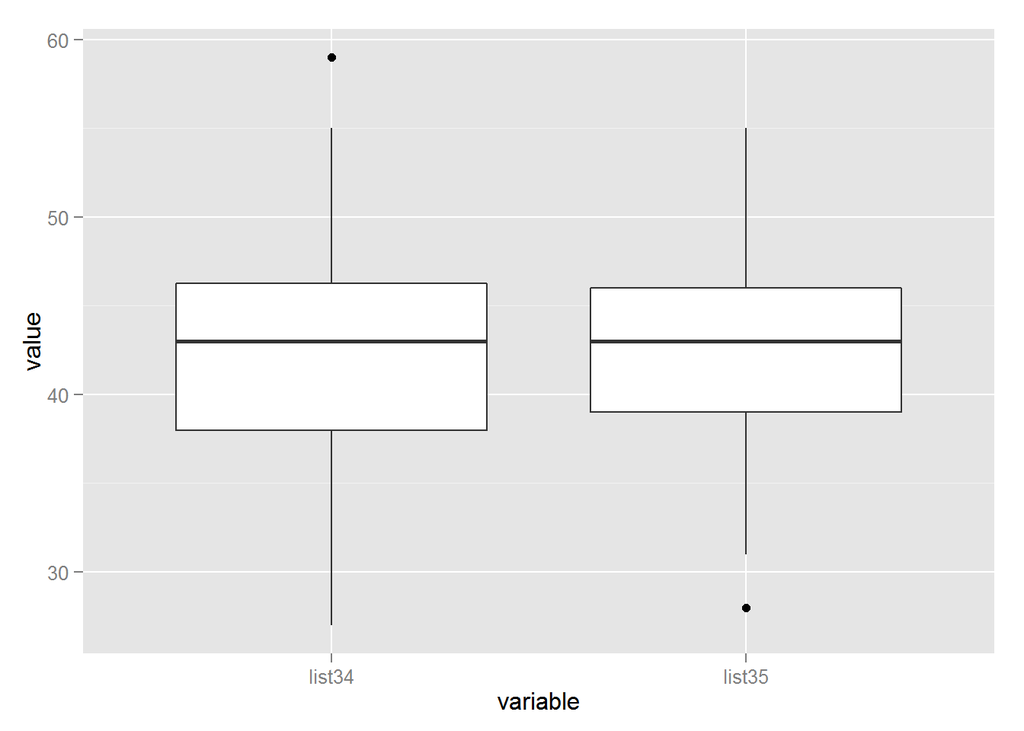

```r
#teeme simulatsiooni, iga 250 loosi kohta võtame 34 ja 35 esinemise sageduse
#kordame 100 korda
library(reshape2)
tulem=data.frame(c(1:8))
names(tulem)="järjekord"
list34=list()
list35=list()
j=1
for (j in 1:100)  {

    tulem=data.frame(c(1:8))
    names(tulem)="järjekord"

        for (i in 1:250)
        {
    tulem[,i+1]=sample(1:48, 8, replace=F)
    names(tulem)[i+1] <- paste("iter", i, sep = "")
        }

    tulem_melt=melt(tulem, id=c("järjekord"))
    #arvutame iga iteratsioonis iga numbri sageduse
    tulem_sagedus=data.frame(table(tulem_melt$value, tulem_melt$variable))
    #hoiame alles ainult 34 ja 35 sagedused, kuna need huvitavad
    tulem_vaja=subset(tulem_sagedus, Var1%in% c(34,35))

    list34[j]=sum(tulem_vaja$Freq[tulem_vaja[,1]==34])
    list35[j]=sum(tulem_vaja$Freq[tulem_vaja[,1]==35])
    j=j+1
}

#teeme dataframeiks listid ja numericuks et ggplottida
simulatsioonid=as.data.frame(rbind(list34, list35))
simulatsioonid=as.data.frame(t(simulatsioonid)) #transpose
simulatsioonid$list34=as.numeric(simulatsioonid$list34)
simulatsioonid$list35=as.numeric(simulatsioonid$list35)
simulatsioonid_melt=melt(simulatsioonid)
simulatsioonid_melt$value=as.numeric(simulatsioonid_melt$value)
#siit on hästi näha, mis on 34 ja 35 esinemissageduste jaotus 250 numrbite
#võtmise korral lotos
ggplot(simulatsioonid_melt, aes(x=variable, y=value))+
    geom_boxplot()
```